# WCBC Tasks

Martin Freisehner & Wilma Weixelbaum

May 29, 2018

### Historic WC Data

Required packages

```r
library(stats)
library(dplyr)
```

```r
library(ggplot2)
library(RColorBrewer)
library(DT)
library(lubridate)
library(stringr)
```

- **Task 1.** Get familiar with the data using `str()`, `head()`, `table()`, `summary()`, etc. Describe the data in a few lines.

```r
WC.history <- read.csv("WorldCupMatches.csv")
head(WC.history)
```

```
##   Year             Datetime   Stage        Stadium        City
## 1 1930 13 Jul 1930 - 15:00  Group 1        Pocitos Montevideo
## 2 1930 13 Jul 1930 - 15:00  Group 4 Parque Central Montevideo
## 3 1930 14 Jul 1930 - 12:45  Group 2 Parque Central Montevideo
## 4 1930 14 Jul 1930 - 14:50  Group 3        Pocitos Montevideo
## 5 1930 15 Jul 1930 - 16:00  Group 1 Parque Central Montevideo
## 6 1930 16 Jul 1930 - 14:45  Group 1 Parque Central Montevideo
##   Home.Team.Name Home.Team.Goals Away.Team.Goals Away.Team.Name
## 1         France               4               1         Mexico
## 2            USA               3               0        Belgium
## 3     Yugoslavia               2               1         Brazil
## 4        Romania               3               1           Peru
## 5      Argentina               1               0         France
## 6          Chile               3               0         Mexico
##   Win.conditions Attendance Half.time.Home.Goals Half.time.Away.Goals
```

[output cut: 27 more lines]

```r
WC.history <- na.omit(WC.history)
# remove rn" from team names
WC.history$Home.Team.Name <- as.factor(sapply(WC.history$Home.Team.Name, function (x) return(gsub("rn\">", "",x))))
WC.history$Away.Team.Name <- as.factor(sapply(WC.history$Away.Team.Name, function (x) return(gsub("rn\">", "",x))))
summary(WC.history)
```

```
##       Year                      Datetime              Stage
##  Min.   :1930   27 May 1934 - 16:30 :  8   Round of 16   : 70
##  1st Qu.:1970   08 Jun 1958 - 19:00 :  7   Quarter-finals: 66
##  Median :1990   11 Jun 1958 - 19:00 :  7   Group 1       : 62
##  Mean   :1985   15 Jun 1958 - 19:00 :  7   Group A       : 60
##  3rd Qu.:2002   02 Jul 1950 - 15:00 :  4   Group B       : 60
##  Max.   :2014   02 Jun 1962 - 15:00 :  4   Group 2       : 59
##                 (Other)             :813   (Other)       :473
##                       Stadium                 City        Home.Team.Name
##  Estadio Azteca           : 19   Mexico City    : 23   Brazil    : 82
##  Jalisco                  : 14   Montevideo     : 18   Italy     : 57
##  Olympiastadion           : 14   Rio De Janeiro : 18   Argentina : 54
##  Nou Camp - Estadio Leï¿½n: 11   Guadalajara    : 17   Germany FR: 43
##  Estadio Centenario       : 10   Johannesburg   : 15   England   : 35
##  Estadio do Maracana      : 10   Sao Paulo      : 14   Germany   : 32
##  (Other)                  :772   (Other)        :745   (Other)   :547
##  Home.Team.Goals  Away.Team.Goals   Away.Team.Name
##  Min.   : 0.000   Min.   :0.000   Mexico   : 38
##  1st Qu.: 1.000   1st Qu.:0.000   France   : 30
##  Median : 2.000   Median :1.000   Spain    : 29
##  Mean   : 1.811   Mean   :1.022   Argentina: 27
##  3rd Qu.: 3.000   3rd Qu.:2.000   England  : 27
##  Max.   :10.000   Max.   :7.000   Brazil   : 26
##                                   (Other)  :673
##                           Win.conditions   Attendance
##                                  :787    Min.   :  2000
##  Italy win after extra time      :  5    1st Qu.: 30000
##  Argentina win after extra time  :  4    Median : 41580
##  Belgium win after extra time    :  3    Mean   : 45165
##  Brazil win on penalties (3 - 2) :  3    3rd Qu.: 61375
##  England win after extra time    :  3    Max.   :173850
##  (Other)                         : 45
##  Half.time.Home.Goals Half.time.Away.Goals                   Referee
##  Min.   :0.0000       Min.   :0.0000       Ravshan IRMATOV (UZB) : 10
##  1st Qu.:0.0000       1st Qu.:0.0000       ARCHUNDIA Benito (MEX):  8
##  Median :0.0000       Median :0.0000       LARRIONDA Jorge (URU) :  8
##  Mean   :0.7106       Mean   :0.4294       QUINIOU Joel (FRA)    :  8
##  3rd Qu.:1.0000       3rd Qu.:1.0000       RODRIGUEZ Marco (MEX) :  8
##  Max.   :6.0000       Max.   :5.0000       BUJSAIM Ali (UAE)     :  7
##                                            (Other)               :801
```

[output cut: 9 more lines]

```
##  Min.   :     201   Min.   :       25   BRA    : 82
##  1st Qu.:     262   1st Qu.:     1188   ITA    : 57
##  Median :     337   Median :     2184   ARG    : 54
##  Mean   :10686257   Mean   : 60784892   FRG    : 43
##  3rd Qu.:  249722   3rd Qu.: 43950058   ENG    : 35
##  Max.   :97410600   Max.   :300186515   GER    : 32
##                                         (Other):547
##  Away.Team.Initials
##  MEX    : 38
##  FRA    : 30
##  ESP    : 29
##  ARG    : 27
##  ENG    : 27
##  BRA    : 26
##  (Other):673
```

In the summary we can see that 3720 lines without information are part of the dataset. Except of that we can also see that the records range from 1930 until 2014. Interesting is that Brazil was the Home Team for 82 and the maximum count for away teams is 38 (Mexico). This shows irregularities between the distribution of teams for home and away position.

```r
summary(WC.history[WC.history$Home.Team.Name=='Brazil',][,c("Year", "Stage", "Away.Team.Name" )])
```

```
##       Year                 Stage           Away.Team.Name
##  Min.   :1930   Quarter-finals:10   Chile         : 5
##  1st Qu.:1962   Group 3       : 9   Czechoslovakia: 5
##  Median :1982   Round of 16   : 9   Sweden        : 5
##  Mean   :1981   Semi-finals   : 7   France        : 4
##  3rd Qu.:2001   Group A       : 6   Mexico        : 4
##  Max.   :2014   Final         : 5   Poland        : 4
##                 (Other)       :36   (Other)       :55
```

Further exploration shows, that a reason for this is the high proportion of finals (Round of 16 and up) for Brazil. The group winner gets assigned as Home-Team in finals, therefore a good team like Brazil shows often up as home team.

- **Task 2.** Write a function that generates the result of the game (W, D, L) from the vectors. How would you incorporate the information in the variable `Win.conditions`?

```r
getResult <- function (entry) {
  if (as.numeric(entry['Home.Team.Goals']) > as.numeric(entry['Away.Team.Goals'])) {
    return("W");
  } else if (as.numeric(entry['Home.Team.Goals']) == as.numeric(entry['Away.Team.Goals'])) {
    # check for penalty information
    if (grepl(entry["Home.Team.Name"], entry['Win.conditions'], fixed=T)) {
      return("W");
    } else if (grepl(entry["Away.Team.Name"], entry['Win.conditions'], fixed=T)) {
      return("L");
    }

    # check for old penalty info
    if (grepl("win on penalties", entry['Win.conditions'], fixed=T)) {
      res <- unlist(strsplit(
        substr(entry['Win.conditions'], nchar(entry['Win.conditions']) - 6, nchar(entry['Win.conditions'])),
        "-"))
      home_goal <- as.numeric(substr(res[1],1,nchar(res[1])))
      away_goal <- as.numeric(substr(res[2],0,nchar(res[2])-2))

      if (home_goal > away_goal) {
        return("W");
      } else {
        return("L");
      }

    }

    return("D");
  } else {
    return("L");
  }
}
WC.history$result <- apply(WC.history,1, getResult)
```

- **Task 3.** Explore the data set using summary statistics and illustrations.
- How often has every nation participated?
- Create a table with the number of wins/draws/losses for ever nation.
- How many goals were scored on average by ever nation?
- etc.

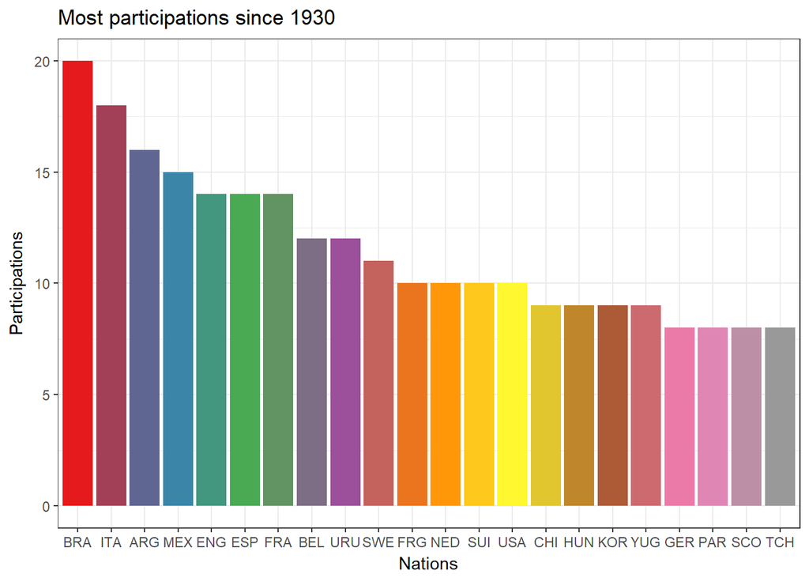

```r
home_match <- WC.history[,c("Year", "Home.Team.Name", "Home.Team.Goals", "Away.Team.Name", "Away.Team.Goals", "Stage", "Home.Team.Initials", "Away.Team.Initials", "result")];
away_match <- WC.history[,c("Year", "Away.Team.Name", "Away.Team.Goals", "Home.Team.Name", "Home.Team.Goals", "Stage", "Away.Team.Initials", "Home.Team.Initials", "result")];

#switch away match to home match (we want a table of format Team vs oppponent and don't care about home/away)
away_match$result <- sapply(away_match$result, function (x) switch(x, "W"="L", "L"="W", "D"))

colnames(away_match) <- colnames(home_match);
WC.matches <- rbind(home_match, away_match);
WC.matches <- arrange(WC.matches, Year);
colnames(WC.matches) <- c("Year", "Team.Name", "Team.Goals", "Opponent.Name", "Opponent.Goals", "Stage", "Team.Initials", "Opponent.Initials", "Result");
participation <- WC.matches %>% distinct(Year, Team.Initials) %>% count(Team.Initials) %>% arrange(desc(n)) %>% top_n(20)
# order by count
participation$Team.Initials <- factor(participation$Team.Initials, levels = participation$Team.Initials[order(participation$n, decreasing=T)])
# show chart
getPalette = colorRampPalette(brewer.pal(9, "Set1"))
participation %>% ggplot(aes(x = Team.Initials, y = n, fill=Team.Initials)) + theme_bw() +
    geom_bar(stat = "identity") +
    labs(title = "Most participations since 1930", x = "Nations", y = "Participations") +
    scale_fill_manual(values = getPalette(length(unique(participation$Team.Initials))),
                      guide = FALSE)
```

```r
WC.teamstats <- WC.matches %>%
  group_by(Team.Initials) %>%
  summarise(Wins = sum(Result=="W"), Draws = sum(Result=="D"), Losses = sum(Result=="L"), Goals.Scored.Avg = mean(Team.Goals), Goals.Allowed.Avg = mean(Opponent.Goals))
datatable(WC.teamstats)
```

|  | Team.Initials | Wins | Draws | Losses | Goals.Scored.Avg | Goals.Allowed.Avg |
| --- | --- | --- | --- | --- | --- | --- |
| 1 | ALG | 3 | 3 | 6 | 1 | 1.41666666666667 |
| 2 | ANG | 0 | 2 | 1 | 0.333333333333333 | 0.666666666666667 |
| 3 | ARG | 49 | 9 | 23 | 1.64197530864198 | 1.04938271604938 |
| 4 | AUS | 2 | 3 | 8 | 0.846153846153846 | 2 |
| 5 | AUT | 12 | 4 | 13 | 1.48275862068966 | 1.62068965517241 |
| 6 | BEL | 16 | 8 | 19 | 1.25581395348837 | 1.58139534883721 |
| 7 | BIH | 1 | 0 | 2 | 1.33333333333333 | 1.33333333333333 |
| 8 | BOL | 0 | 1 | 5 | 0.166666666666667 | 3.33333333333333 |
| 9 | BRA | 75 | 13 | 20 | 2.08333333333333 | 1.05555555555556 |
| 10 | BUL | 4 | 7 | 15 | 0.846153846153846 | 2.03846153846154 |

[output cut: 72 more lines]

* **Task 4.** Do you think this data set can be used to build a predictor function?

While this data only allows simple classifiers it still can be used for predictor functions. A very simple solution would be a predictor that depends on previous results of the teams. For teams that haven’t played against each other the general proportion of wins/draws/losses can be checked. Influence of matches could also be weighted more if they took place in the less distant future. Overall one can say that every little piece of information can be used for the predictor, but the results we can expect from a predictor which incorporates only this historical data most probably won’t be very accurate.

### FIFA Ranking Data

- **Task 5.** Get familiar with the data using `str()`, `head()`, `table()`, `summary()`, etc.

```r
fifa.ranking <- read.csv("fifa_ranking.csv")
fifa.ranking$rank_date <- as.Date(fifa.ranking$rank_date, "%Y-%m-%d")
summary(fifa.ranking)
```

```
##       rank                    country_full    country_abrv
##  Min.   :  1.0   Sudan              :  324   SDN    :  324
##  1st Qu.: 51.0   Albania            :  285   ALB    :  285
##  Median :101.0   Algeria            :  285   ALG    :  285
##  Mean   :101.6   Angola             :  285   ANG    :  285
##  3rd Qu.:152.0   Antigua and Barbuda:  285   ARG    :  285
##  Max.   :209.0   Argentina          :  285   ARU    :  285
##                  (Other)            :55833   (Other):55833
##   total_points     previous_points   rank_change         cur_year_avg
##  Min.   :   0.00   Min.   :   0.0   Min.   :-72.00000   Min.   :   0.00
##  1st Qu.:   0.00   1st Qu.:  56.0   1st Qu.: -2.00000   1st Qu.:   0.00
##  Median :   0.00   Median : 272.0   Median :  0.00000   Median :   0.00
##  Mean   : 121.06   Mean   : 332.1   Mean   : -0.01006   Mean   :  61.36
##  3rd Qu.:  87.55   3rd Qu.: 525.0   3rd Qu.:  1.00000   3rd Qu.:  27.92
##  Max.   :1775.03   Max.   :1920.0   Max.   : 92.00000   Max.   :1158.66
##
##  cur_year_avg_weighted last_year_avg     last_year_avg_weighted
##  Min.   :   0.00       Min.   :   0.00   Min.   :  0.00
##  1st Qu.:   0.00       1st Qu.:   0.00   1st Qu.:  0.00
##  Median :   0.00       Median :   0.00   Median :  0.00
##  Mean   :  61.36       Mean   :  60.45   Mean   : 30.22
##  3rd Qu.:  27.92       3rd Qu.:  25.80   3rd Qu.: 12.90
##  Max.   :1158.66       Max.   :1169.57   Max.   :584.79
##
##  two_year_ago_avg  two_year_ago_weighted three_year_ago_avg
##  Min.   :   0.00   Min.   :  0.000       Min.   :   0.00
##  1st Qu.:   0.00   1st Qu.:  0.000       1st Qu.:   0.00
##  Median :   0.00   Median :  0.000       Median :   0.00
##  Mean   :  59.21   Mean   : 17.763       Mean   :  58.60
##  3rd Qu.:  19.52   3rd Qu.:  5.855       3rd Qu.:  17.71
##  Max.   :1159.71   Max.   :347.910       Max.   :1158.66
##
##  three_year_ago_weighted  confederation     rank_date
##  Min.   :  0.00          AFC     :12571   Min.   :1993-08-08
##  1st Qu.:  0.00          CAF     :14822   1st Qu.:2000-10-11
##  Median :  0.00          CONCACAF: 9629   Median :2006-11-22
##  Mean   : 11.72          CONMEBOL: 2850   Mean   :2006-08-21
##  3rd Qu.:  3.54          OFC     : 2832   3rd Qu.:2012-09-05
##  Max.   :231.73          UEFA    :14878   Max.   :2018-05-17
##
```

```r
# fetch the 'regular' amount of appearences per country
reg_amount <- fifa.ranking %>% group_by(country_full) %>% summarize(n = n()) %>% group_by(n) %>% summarize(n_countries = n()) %>% arrange(desc(n_countries)) %>% top_n(1)
# fetch the amount of different dates
date_amount <- fifa.ranking %>% distinct(rank_date) %>% summarize(n = n())

# get dates for SUDAN (!!duplicates!!)
sdn_dates <- fifa.ranking[fifa.ranking$country_abrv=='SDN',] %>% group_by(rank_date) %>% summarize(n=n()) %>% filter(n>1)
```

A first look at the data shows that the rankings range from 08.08.1993 to 17.05.2018 Most countries appear exactly 285 times. All other countries except Sudan appear less often. This has different reasons (e.g. political - a countries football association might have not been a part of FIFA,..). The dataset also has recordings for 285 different dates, which matches the number of ‘regular’ appearences. This also shows that we have far more entries than we need. The most relevant score is the one immediately before the start of the WC. For the special case of Sudan we can find multiple entries per day. As Sudan is not part of the current WC this problem can be ignored.

- **Task 6.** What is the class of `fifa.ranking$rank_date`? Is this a problem? Can you change it to class `date` using `as.Date`? What difference does this make for e.g. plotting?

The class is ‘factor’ which causes problems as we want the dates to be continous. If we don’t change the class the correct ordering and the correct distance between datapoints is not correctly derivable. In a plot we might see datapoints in wrong order or wrong distance from each other.

- **Task 7.** Plot the FIFA ranks for a selection of favorites

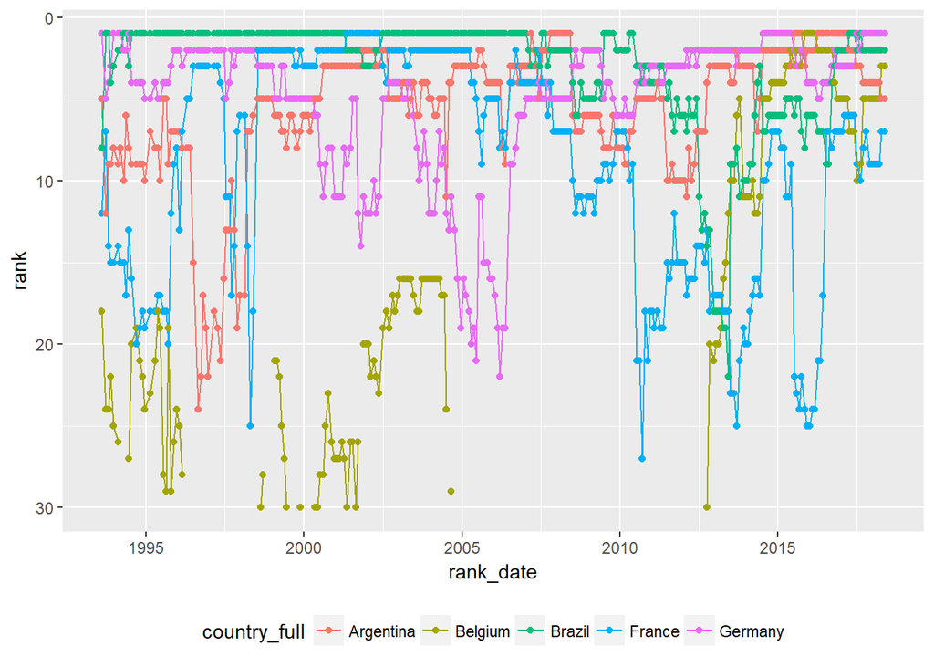

```r
favorites <- c("Germany", "Brazil", "Belgium", "France", "Argentina")
favorite_ranks <- fifa.ranking %>% filter(country_full %in% favorites) %>% select(rank, country_full, rank_date)
ggplot(data=favorite_ranks, aes(x=rank_date, y=rank, group=country_full)) +
  geom_line(aes(color=country_full)) +
  geom_point(aes(color=country_full)) +
  scale_y_reverse(limits=c(30,1)) +
  theme(legend.position="bottom")
```

If you use `ggplot()` don’t forget to `scale_y_reverse()``

### Transfermarkt.de Data

- **Task 8.** Have a look at the following web site https://www.transfermarkt.com/weltmeisterschaft-2018/startseite/pokalwettbewerb/WM18. Where can you find detailed information from the past world cups?

Via https://www.transfermarkt.com/weltmeisterschaft-2018/turnierbilanz/pokalwettbewerb/WM18 all other worldcups are linked. With a click on the respective year detailed information can be fetched via several links in the submenu.

- **Task 9.** (voluntary) Browse the vignette of the following package:

```r
library(rvest)
```

- **Task 10.** (voluntary) How can you scrape the relevant information of the following websites (in the order of the vector `participants`)?

NOTE: Code taken from https://github.com/SchroederFabian

```r
  if (! exists("team.info")) {

    WC.hist.tmp <- read.csv("WorldCupMatches.csv", stringsAsFactors = FALSE) # load data

    # 3.2 basic formatting
    WC.hist.tmp <- WC.hist.tmp[1:852,] # delete empty rows
    WC.hist.tmp$Home.Team.Name <- gsub("rn\">", "", WC.hist.tmp$Home.Team.Name)
    WC.hist.tmp$Home.Team.Name[grepl("Ivoire", WC.hist.tmp$Home.Team.Name)] <- "Ivory Coast"
    WC.hist.tmp$Away.Team.Name <- gsub("rn\">", "", WC.hist.tmp$Away.Team.Name)
    WC.hist.tmp$Away.Team.Name[grepl("Ivoire", WC.hist.tmp$Away.Team.Name)] <- "Ivory Coast"
    WC.hist.tmp$Datetime <- lubridate::dmy_hm(WC.hist.tmp$Datetime)

    # map country name to unique identifier
    init.maps <- unique(cbind(c(WC.hist.tmp$Home.Team.Name, WC.hist.tmp$Away.Team.Name), c(WC.hist.tmp$Home.Team.Initials, WC.hist.tmp$Away.Team.Initials)))
    init.maps <- init.maps[order(init.maps[,1]),]
    init.maps <- rbind(init.maps, c("Iceland", "ISL"))
    init.maps <- rbind(init.maps, c("Panama", "PAN"))

  # 5.1 scrape the links of the team websites

    links.lst <- c( "https://www.transfermarkt.com/weltmeisterschaft-2018/teilnehmer/pokalwettbewerb/WM18/saison_id/2017",
                    "https://www.transfermarkt.com/weltmeisterschaft-2014/teilnehmer/pokalwettbewerb/WM14/saison_id/2013",
                    "https://www.transfermarkt.com/weltmeisterschaft-2010/teilnehmer/pokalwettbewerb/WM10/saison_id/2009",
                    "https://www.transfermarkt.com/weltmeisterschaft-2006/teilnehmer/pokalwettbewerb/WM06/saison_id/2005",
                    "https://www.transfermarkt.com/weltmeisterschaft-2002/teilnehmer/pokalwettbewerb/WM02/saison_id/2001")

    names(links.lst) <- c("2018", "2014", "2010", "2006", "2002")

    team.info <- data.frame("Year" = numeric(),
                            "Team" = character(),
                            "Name" = character(),
                            "Number" = numeric(),
                            "Position" = character(),
                            "Born" = as.Date(x=rep("01/01/0", length = 0), format="%d/%m/%Y"),
                            "Age" = numeric(),
                            "Height" = numeric(),
                            "Foot" = character(),
                            "Caps" = numeric(),
                            "Goals" = numeric(),
                            "Debut" = as.Date(x=rep("01/01/0", length = 0), format="%d/%m/%Y"),
                            "Market Value" = numeric(),
                            stringsAsFactors = FALSE)


    for (k in 1:length(links.lst)) {
      # scrape the links of the team websites
      links.site <- read_html(links.lst[k])
      selector <- ifelse(as.numeric(names(links.lst)[k]) == 2018, "#yw1 .hauptlink , #yw2 .hauptlink", ".hauptlink")
      links.names <- links.site %>% html_nodes(selector) %>% html_children() %>% html_text()
      links <- links.site %>% html_nodes(selector) %>% html_children() %>% html_attr("href")
      links <- paste0("https://www.transfermarkt.de", links)
      links <- gsub("startseite", "kader", links)
      links <- paste0(links, "/saison_id/",as.numeric(names(links.lst)[k])-1,"/plus/1")
      links.names <- str_replace(links.names, "Bosnia-Herzegovina", "Bosnia and Herzegovina")
      links.names <- str_replace(links.names, "South Korea", "Korea Republic")
      links.names <- str_replace(links.names, "United States", "USA" )
      links.names <- str_replace(links.names, "North Korea", "Korea DPR")
      links.names <- str_replace(links.names, "China", "China PR")

      #print(all(links.names %in% init.maps[,1]))

      ord <- match(links.names, init.maps[,1])
      links.init <- init.maps[ord,2]

      if (names(links.lst)[k]=="2006") { links <- links[-33]}

      for (j in 1:length(links)) {
        print(links[j])

        ws <- read_html(links[j])

        ws %>%
          html_nodes(".items") %>%
          html_children() %>%
          magrittr::extract(2) %>%
          html_children() -> elements

        n.team <- length(elements)
        team.info.sub <- data.frame("Year" = numeric(length = n.team),
                                    "Team" = character(length = n.team),
                                    "Name" = character(length = n.team),
                                    "Number" = numeric(length = n.team),
                                    "Position" = character(length = n.team),
                                    "Born" = as.Date(x=rep("01/01/0", length = n.team), format="%d/%m/%Y"),
                                    "Age" = numeric(length = n.team),
                                    "Height" = numeric(length = n.team),
                                    "Foot" = character(length = n.team),
                                    "Caps" = numeric(length = n.team),
                                    "Goals" = numeric(length = n.team),
                                    "Debut" = as.Date(x=rep("01/01/0", length = n.team), format="%d/%m/%Y"),
                                    "Market Value" = numeric(length = n.team),
                                    stringsAsFactors = FALSE)

        for (i in 1:length(elements)) {

          team.info.sub[i,1] <- as.numeric(names(links.lst)[k]) # year
          team.info.sub[i,2] <- links.init[j] # team
          team.info.sub[i,3] <- html_text(html_children(html_nodes(html_children(elements[i])[2], "td")[2])[1]) # player
          team.info.sub[i,4] <- as.numeric(html_text(html_children(html_children(elements[i])[1]))) # number
          team.info.sub[i,5] <- html_text(html_nodes(elements[i], "td")[5]) # position
          team.info.sub[i,6] <- dmy(strsplit(html_text(html_children(elements[i])[3]), " ")[[1]][1]) # born
          team.info.sub[i,7] <- as.numeric(gsub("\\)","", gsub("\\(", "", strsplit(html_text(html_children(elements[i])[3]), " ")[[1]][2]))) # age
          team.info.sub[i,8] <- as.numeric(gsub(",", ".", gsub(" m", "", html_text(html_children(elements[i])[5])))) # heigth
          team.info.sub[i,9] <- html_text(html_children(elements[i])[6]) # foot

          if (names(links.lst[k]) == "2018") {
            team.info.sub[i,10] <- as.numeric(ifelse(html_text(html_children(elements[i])[7]) == "-", 0, html_text(html_children(elements[i])[7]))) # caps
            team.info.sub[i,11] <- as.numeric(ifelse(html_text(html_children(elements[i])[8]) == "-", 0, html_text(html_children(elements[i])[8]))) # goals
            team.info.sub[i,12] <- dmy(ifelse(html_text(html_children(elements[i])[9]) == "-", NA, html_text(html_children(elements[i])[9]))) # debut
          } else {
            team.info.sub[i,10] <- NA # caps
            team.info.sub[i,11] <- NA # goals
            team.info.sub[i,12] <- NA # debut
          }

          # market value
          mv.tmp <- html_text(html_children(elements[i])[10])

          if (grepl("Mio", mv.tmp)) {
            team.info.sub[i,13] <- as.numeric(gsub(",", ".", strsplit(mv.tmp, " ")[[1]][1])) * 1000000
          } else if(grepl("Tsd", mv.tmp)) {
            team.info.sub[i,13] <- as.numeric(gsub(",", ".", strsplit(mv.tmp, " ")[[1]][1])) * 1000
          }

        }

        team.info <- rbind(team.info, team.info.sub)
      }

    }
  }
```

```
## [1] "https://www.transfermarkt.de/frankreich/kader/verein/3377/saison_id/2017/plus/1"
```

```
## [1] "https://www.transfermarkt.de/kroatien/kader/verein/3556/saison_id/2017/plus/1"
```

```
## [1] "https://www.transfermarkt.de/spanien/kader/verein/3375/saison_id/2017/plus/1"
```

```
## [1] "https://www.transfermarkt.de/deutschland/kader/verein/3262/saison_id/2017/plus/1"
## [1] "https://www.transfermarkt.de/brasilien/kader/verein/3439/saison_id/2017/plus/1"
```

```
## [1] "https://www.transfermarkt.de/england/kader/verein/3299/saison_id/2017/plus/1"
```

```
## [1] "https://www.transfermarkt.de/belgien/kader/verein/3382/saison_id/2017/plus/1"
```

```
## [1] "https://www.transfermarkt.de/argentinien/kader/verein/3437/saison_id/2017/plus/1"
```

[output not shown]

```
## [1] "https://www.transfermarkt.de/portugal/kader/verein/3300/saison_id/2017/plus/1"
```

```
## [1] "https://www.transfermarkt.de/uruguay/kader/verein/3449/saison_id/2017/plus/1"
```

```
## [1] "https://www.transfermarkt.de/senegal/kader/verein/3499/saison_id/2017/plus/1"
```

```
## [1] "https://www.transfermarkt.de/serbien/kader/verein/3438/saison_id/2017/plus/1"
```

```
## [1] "https://www.transfermarkt.de/polen/kader/verein/3442/saison_id/2017/plus/1"
```

[output not shown]

```
## [1] "https://www.transfermarkt.de/schweiz/kader/verein/3384/saison_id/2017/plus/1"
```

```
## [1] "https://www.transfermarkt.de/agypten/kader/verein/3672/saison_id/2017/plus/1"
```

```
## [1] "https://www.transfermarkt.de/kolumbien/kader/verein/3816/saison_id/2017/plus/1"
```

```
## [1] "https://www.transfermarkt.de/nigeria/kader/verein/3444/saison_id/2017/plus/1"
```

```
## [1] "https://www.transfermarkt.de/russland/kader/verein/3448/saison_id/2017/plus/1"
## [1] "https://www.transfermarkt.de/marokko/kader/verein/3575/saison_id/2017/plus/1"
```

```
## [1] "https://www.transfermarkt.de/mexiko/kader/verein/6303/saison_id/2017/plus/1"
```

[output not shown]

```
## [1] "https://www.transfermarkt.de/schweden/kader/verein/3557/saison_id/2017/plus/1"
```

```
## [1] "https://www.transfermarkt.de/sudkorea/kader/verein/3589/saison_id/2017/plus/1"
```

```
## [1] "https://www.transfermarkt.de/island/kader/verein/3574/saison_id/2017/plus/1"
```

[output not shown]

```
## [1] "https://www.transfermarkt.de/iran/kader/verein/3582/saison_id/2017/plus/1"
```

```
## [1] "https://www.transfermarkt.de/tunesien/kader/verein/3670/saison_id/2017/plus/1"
```

```
## [1] "https://www.transfermarkt.de/australien/kader/verein/3433/saison_id/2017/plus/1"
```

```
## [1] "https://www.transfermarkt.de/japan/kader/verein/3435/saison_id/2017/plus/1"
```

[output not shown]

```
## [1] "https://www.transfermarkt.de/peru/kader/verein/3584/saison_id/2017/plus/1"
```

```
## [1] "https://www.transfermarkt.de/saudi-arabien/kader/verein/3807/saison_id/2017/plus/1"
## [1] "https://www.transfermarkt.de/costa-rica/kader/verein/8497/saison_id/2017/plus/1"
```

```
## [1] "https://www.transfermarkt.de/panama/kader/verein/3577/saison_id/2017/plus/1"
```

```
## [1] "https://www.transfermarkt.de/danemark/kader/verein/3436/saison_id/2017/plus/1"
```

[output not shown]

```
## [1] "https://www.transfermarkt.de/deutschland/kader/verein/3262/saison_id/2013/plus/1"
```

[output not shown]

```
## [1] "https://www.transfermarkt.de/argentinien/kader/verein/3437/saison_id/2013/plus/1"
```

```
## [1] "https://www.transfermarkt.de/frankreich/kader/verein/3377/saison_id/2013/plus/1"
```

```
## [1] "https://www.transfermarkt.de/spanien/kader/verein/3375/saison_id/2013/plus/1"
```

[output not shown]

```
## [1] "https://www.transfermarkt.de/brasilien/kader/verein/3439/saison_id/2013/plus/1"
```

```
## [1] "https://www.transfermarkt.de/england/kader/verein/3299/saison_id/2013/plus/1"
```

```
## [1] "https://www.transfermarkt.de/italien/kader/verein/3376/saison_id/2013/plus/1"
```

[output not shown]

```
## [1] "https://www.transfermarkt.de/belgien/kader/verein/3382/saison_id/2013/plus/1"
```

```
## [1] "https://www.transfermarkt.de/niederlande/kader/verein/3379/saison_id/2013/plus/1"
```

[output not shown]

```
## [1] "https://www.transfermarkt.de/portugal/kader/verein/3300/saison_id/2013/plus/1"
```

[output not shown]

```
## [1] "https://www.transfermarkt.de/kroatien/kader/verein/3556/saison_id/2013/plus/1"
```

[output not shown]

```
## [1] "https://www.transfermarkt.de/uruguay/kader/verein/3449/saison_id/2013/plus/1"
```

```
## [1] "https://www.transfermarkt.de/schweiz/kader/verein/3384/saison_id/2013/plus/1"
```

```
## [1] "https://www.transfermarkt.de/algerien/kader/verein/3614/saison_id/2013/plus/1"
```

[output not shown]

```
## [1] "https://www.transfermarkt.de/kolumbien/kader/verein/3816/saison_id/2013/plus/1"
```

```
## [1] "https://www.transfermarkt.de/elfenbeinkuste/kader/verein/3591/saison_id/2013/plus/1"
```

```
## [1] "https://www.transfermarkt.de/bosnien-herzegowina/kader/verein/3446/saison_id/2013/plus/1"
```

```
## [1] "https://www.transfermarkt.de/nigeria/kader/verein/3444/saison_id/2013/plus/1"
```

```
## [1] "https://www.transfermarkt.de/russland/kader/verein/3448/saison_id/2013/plus/1"
```

```
## [1] "https://www.transfermarkt.de/kamerun/kader/verein/3434/saison_id/2013/plus/1"
```

[output not shown]

```
## [1] "https://www.transfermarkt.de/mexiko/kader/verein/6303/saison_id/2013/plus/1"
```

[output not shown]

[output cut: 8 more lines]

[output not shown]

```
## [1] "https://www.transfermarkt.de/griechenland/kader/verein/3378/saison_id/2013/plus/1"
```

```
## [1] "https://www.transfermarkt.de/chile/kader/verein/3700/saison_id/2013/plus/1"
```

[output not shown]

```
## [1] "https://www.transfermarkt.de/ghana/kader/verein/3441/saison_id/2013/plus/1"
```

```
## [1] "https://www.transfermarkt.de/sudkorea/kader/verein/3589/saison_id/2013/plus/1"
```

[output not shown]

```
## [1] "https://www.transfermarkt.de/iran/kader/verein/3582/saison_id/2013/plus/1"
```

```
## [1] "https://www.transfermarkt.de/vereinigte-staaten/kader/verein/3505/saison_id/2013/plus/1"
```

[output not shown]

[output cut: 40 more lines]

[output not shown]

```
## [1] "https://www.transfermarkt.de/australien/kader/verein/3433/saison_id/2013/plus/1"
```

[output not shown]

```
## [1] "https://www.transfermarkt.de/japan/kader/verein/3435/saison_id/2013/plus/1"
```

[output not shown]

```
## [1] "https://www.transfermarkt.de/ecuador/kader/verein/5750/saison_id/2013/plus/1"
```

```
## [1] "https://www.transfermarkt.de/costa-rica/kader/verein/8497/saison_id/2013/plus/1"
```

[output not shown]

```
## [1] "https://www.transfermarkt.de/honduras/kader/verein/3590/saison_id/2013/plus/1"
```

[output not shown]

```
## [1] "https://www.transfermarkt.de/spanien/kader/verein/3375/saison_id/2009/plus/1"
```

```
## [1] "https://www.transfermarkt.de/niederlande/kader/verein/3379/saison_id/2009/plus/1"
```

```
## [1] "https://www.transfermarkt.de/frankreich/kader/verein/3377/saison_id/2009/plus/1"
```

```
## [1] "https://www.transfermarkt.de/deutschland/kader/verein/3262/saison_id/2009/plus/1"
```

[output not shown]

```
## [1] "https://www.transfermarkt.de/brasilien/kader/verein/3439/saison_id/2009/plus/1"
```

```
## [1] "https://www.transfermarkt.de/england/kader/verein/3299/saison_id/2009/plus/1"
```

[output not shown]

```
## [1] "https://www.transfermarkt.de/italien/kader/verein/3376/saison_id/2009/plus/1"
```

```
## [1] "https://www.transfermarkt.de/argentinien/kader/verein/3437/saison_id/2009/plus/1"
```

[output not shown]

[output cut: 46 more lines]

[output not shown]

```
## [1] "https://www.transfermarkt.de/portugal/kader/verein/3300/saison_id/2009/plus/1"
```

```
## [1] "https://www.transfermarkt.de/uruguay/kader/verein/3449/saison_id/2009/plus/1"
```

```
## [1] "https://www.transfermarkt.de/serbien/kader/verein/3438/saison_id/2009/plus/1"
```

[output not shown]

```
## [1] "https://www.transfermarkt.de/schweiz/kader/verein/3384/saison_id/2009/plus/1"
```

```
## [1] "https://www.transfermarkt.de/algerien/kader/verein/3614/saison_id/2009/plus/1"
```

```
## [1] "https://www.transfermarkt.de/elfenbeinkuste/kader/verein/3591/saison_id/2009/plus/1"
```

```
## [1] "https://www.transfermarkt.de/nigeria/kader/verein/3444/saison_id/2009/plus/1"
```

[output not shown]

```
## [1] "https://www.transfermarkt.de/slowakei/kader/verein/3503/saison_id/2009/plus/1"
```

```
## [1] "https://www.transfermarkt.de/kamerun/kader/verein/3434/saison_id/2009/plus/1"
```

```
## [1] "https://www.transfermarkt.de/mexiko/kader/verein/6303/saison_id/2009/plus/1"
```

[output not shown]

```
## [1] "https://www.transfermarkt.de/griechenland/kader/verein/3378/saison_id/2009/plus/1"
```

```
## [1] "https://www.transfermarkt.de/chile/kader/verein/3700/saison_id/2009/plus/1"
```

[output not shown]

[output cut: 14 more lines]

[output not shown]

```
## [1] "https://www.transfermarkt.de/ghana/kader/verein/3441/saison_id/2009/plus/1"
```

[output not shown]

[output cut: 8 more lines]

[output not shown]

```
## [1] "https://www.transfermarkt.de/sudkorea/kader/verein/3589/saison_id/2009/plus/1"
```

[output not shown]

```
## [1] "https://www.transfermarkt.de/slowenien/kader/verein/3588/saison_id/2009/plus/1"
```

```
## [1] "https://www.transfermarkt.de/vereinigte-staaten/kader/verein/3505/saison_id/2009/plus/1"
```

[output not shown]

[output cut: 12 more lines]

[output not shown]

```
## [1] "https://www.transfermarkt.de/australien/kader/verein/3433/saison_id/2009/plus/1"
```

[output not shown]

[output cut: 14 more lines]

[output not shown]

```
## [1] "https://www.transfermarkt.de/paraguay/kader/verein/3581/saison_id/2009/plus/1"
```

[output not shown]

```
## [1] "https://www.transfermarkt.de/japan/kader/verein/3435/saison_id/2009/plus/1"
```

[output not shown]

```
## [1] "https://www.transfermarkt.de/sudafrika/kader/verein/3806/saison_id/2009/plus/1"
```

[output not shown]

```
## [1] "https://www.transfermarkt.de/neuseeland/kader/verein/9171/saison_id/2009/plus/1"
```

```
## [1] "https://www.transfermarkt.de/honduras/kader/verein/3590/saison_id/2009/plus/1"
```

[output not shown]

```
## [1] "https://www.transfermarkt.de/danemark/kader/verein/3436/saison_id/2009/plus/1"
```

[output not shown]

```
## [1] "https://www.transfermarkt.de/nordkorea/kader/verein/15457/saison_id/2009/plus/1"
```

```
## [1] "https://www.transfermarkt.de/frankreich/kader/verein/3377/saison_id/2005/plus/1"
```

```
## [1] "https://www.transfermarkt.de/italien/kader/verein/3376/saison_id/2005/plus/1"
```

```
## [1] "https://www.transfermarkt.de/spanien/kader/verein/3375/saison_id/2005/plus/1"
```

```
## [1] "https://www.transfermarkt.de/deutschland/kader/verein/3262/saison_id/2005/plus/1"
```

```
## [1] "https://www.transfermarkt.de/brasilien/kader/verein/3439/saison_id/2005/plus/1"
```

```
## [1] "https://www.transfermarkt.de/england/kader/verein/3299/saison_id/2005/plus/1"
```

[output not shown]

```
## [1] "https://www.transfermarkt.de/argentinien/kader/verein/3437/saison_id/2005/plus/1"
```

[output not shown]

```
## [1] "https://www.transfermarkt.de/niederlande/kader/verein/3379/saison_id/2005/plus/1"
```

[output not shown]

```
## [1] "https://www.transfermarkt.de/portugal/kader/verein/3300/saison_id/2005/plus/1"
```

```
## [1] "https://www.transfermarkt.de/kroatien/kader/verein/3556/saison_id/2005/plus/1"
```

[output not shown]

```
## [1] "https://www.transfermarkt.de/polen/kader/verein/3442/saison_id/2005/plus/1"
```

[output not shown]

```
## [1] "https://www.transfermarkt.de/schweiz/kader/verein/3384/saison_id/2005/plus/1"
```

[output not shown]

```
## [1] "https://www.transfermarkt.de/elfenbeinkuste/kader/verein/3591/saison_id/2005/plus/1"
```

```
## [1] "https://www.transfermarkt.de/ukraine/kader/verein/3699/saison_id/2005/plus/1"
```

[output not shown]

```
## [1] "https://www.transfermarkt.de/mexiko/kader/verein/6303/saison_id/2005/plus/1"
```

[output not shown]

```
## [1] "https://www.transfermarkt.de/schweden/kader/verein/3557/saison_id/2005/plus/1"
```

[output not shown]

[output cut: 10 more lines]

[output not shown]

```
## [1] "https://www.transfermarkt.de/tschechien/kader/verein/3445/saison_id/2005/plus/1"
```

[output not shown]

[output cut: 16 more lines]

[output not shown]

```
## [1] "https://www.transfermarkt.de/ghana/kader/verein/3441/saison_id/2005/plus/1"
```

[output not shown]

```
## [1] "https://www.transfermarkt.de/sudkorea/kader/verein/3589/saison_id/2005/plus/1"
```

```
## [1] "https://www.transfermarkt.de/iran/kader/verein/3582/saison_id/2005/plus/1"
```

[output not shown]

```
## [1] "https://www.transfermarkt.de/vereinigte-staaten/kader/verein/3505/saison_id/2005/plus/1"
```

[output not shown]

[output cut: 38 more lines]

[output not shown]

```
## [1] "https://www.transfermarkt.de/tunesien/kader/verein/3670/saison_id/2005/plus/1"
```

```
## [1] "https://www.transfermarkt.de/australien/kader/verein/3433/saison_id/2005/plus/1"
```

```
## [1] "https://www.transfermarkt.de/paraguay/kader/verein/3581/saison_id/2005/plus/1"
```

```
## [1] "https://www.transfermarkt.de/japan/kader/verein/3435/saison_id/2005/plus/1"
```

```
## [1] "https://www.transfermarkt.de/ecuador/kader/verein/5750/saison_id/2005/plus/1"
```

```
## [1] "https://www.transfermarkt.de/togo/kader/verein/3815/saison_id/2005/plus/1"
```

```
## [1] "https://www.transfermarkt.de/saudi-arabien/kader/verein/3807/saison_id/2005/plus/1"
```

```
## [1] "https://www.transfermarkt.de/angola/kader/verein/3585/saison_id/2005/plus/1"
```

```
## [1] "https://www.transfermarkt.de/costa-rica/kader/verein/8497/saison_id/2005/plus/1"
```

```
## [1] "https://www.transfermarkt.de/trinidad-amp-tobago/kader/verein/7149/saison_id/2005/plus/1"
```

```
## [1] "https://www.transfermarkt.de/serbien-und-montenegro/kader/verein/23380/saison_id/2005/plus/1"
```

```
## [1] "https://www.transfermarkt.de/deutschland/kader/verein/3262/saison_id/2001/plus/1"
```

[output not shown]

[output not shown]

```
## [1] "https://www.transfermarkt.de/brasilien/kader/verein/3439/saison_id/2001/plus/1"
```

```
## [1] "https://www.transfermarkt.de/frankreich/kader/verein/3377/saison_id/2001/plus/1"
```

```
## [1] "https://www.transfermarkt.de/spanien/kader/verein/3375/saison_id/2001/plus/1"
```

```
## [1] "https://www.transfermarkt.de/england/kader/verein/3299/saison_id/2001/plus/1"
```

[output not shown]

```
## [1] "https://www.transfermarkt.de/italien/kader/verein/3376/saison_id/2001/plus/1"
```

```
## [1] "https://www.transfermarkt.de/belgien/kader/verein/3382/saison_id/2001/plus/1"
```

```
## [1] "https://www.transfermarkt.de/argentinien/kader/verein/3437/saison_id/2001/plus/1"
```

```
## [1] "https://www.transfermarkt.de/portugal/kader/verein/3300/saison_id/2001/plus/1"
```

[output not shown]

[output cut: 18 more lines]

[output not shown]

```
## [1] "https://www.transfermarkt.de/kroatien/kader/verein/3556/saison_id/2001/plus/1"
```

[output not shown]

```
## [1] "https://www.transfermarkt.de/uruguay/kader/verein/3449/saison_id/2001/plus/1"
```

[output not shown]

```
## [1] "https://www.transfermarkt.de/senegal/kader/verein/3499/saison_id/2001/plus/1"
## [1] "https://www.transfermarkt.de/polen/kader/verein/3442/saison_id/2001/plus/1"
```

[output not shown]

[output cut: 64 more lines]

[output not shown]

```
## [1] "https://www.transfermarkt.de/turkei/kader/verein/3381/saison_id/2001/plus/1"
```

```
## [1] "https://www.transfermarkt.de/nigeria/kader/verein/3444/saison_id/2001/plus/1"
```

```
## [1] "https://www.transfermarkt.de/russland/kader/verein/3448/saison_id/2001/plus/1"
```

```
## [1] "https://www.transfermarkt.de/kamerun/kader/verein/3434/saison_id/2001/plus/1"
```

```
## [1] "https://www.transfermarkt.de/mexiko/kader/verein/6303/saison_id/2001/plus/1"
```

```
## [1] "https://www.transfermarkt.de/schweden/kader/verein/3557/saison_id/2001/plus/1"
```

[output not shown]

[output cut: 14 more lines]

[output not shown]

```
## [1] "https://www.transfermarkt.de/sudkorea/kader/verein/3589/saison_id/2001/plus/1"
```

```
## [1] "https://www.transfermarkt.de/irland/kader/verein/3509/saison_id/2001/plus/1"
```

[output not shown]

```
## [1] "https://www.transfermarkt.de/slowenien/kader/verein/3588/saison_id/2001/plus/1"
```

[output not shown]

[output cut: 12 more lines]

[output not shown]

```
## [1] "https://www.transfermarkt.de/vereinigte-staaten/kader/verein/3505/saison_id/2001/plus/1"
```

```
## [1] "https://www.transfermarkt.de/tunesien/kader/verein/3670/saison_id/2001/plus/1"
```

[output not shown]

```
## [1] "https://www.transfermarkt.de/paraguay/kader/verein/3581/saison_id/2001/plus/1"
## [1] "https://www.transfermarkt.de/japan/kader/verein/3435/saison_id/2001/plus/1"
```

[output not shown]

```
## [1] "https://www.transfermarkt.de/ecuador/kader/verein/5750/saison_id/2001/plus/1"
```

```
## [1] "https://www.transfermarkt.de/sudafrika/kader/verein/3806/saison_id/2001/plus/1"
```

```
## [1] "https://www.transfermarkt.de/saudi-arabien/kader/verein/3807/saison_id/2001/plus/1"
```

[output not shown]

```
## [1] "https://www.transfermarkt.de/china/kader/verein/5598/saison_id/2001/plus/1"
```

```
## [1] "https://www.transfermarkt.de/costa-rica/kader/verein/8497/saison_id/2001/plus/1"
```

```
## [1] "https://www.transfermarkt.de/danemark/kader/verein/3436/saison_id/2001/plus/1"
```

[output not shown]

[output cut: 16 more lines]

[output not shown]

What kind of css selectors are there? https://www.w3schools.com/cssref/css_selectors.asp How can you use them to extract the information?

hint: use `read_html()`, `html_nodes()` with the css selectors “.item” or “td”, `html_children()`, etc.

### Socio-economic Data

- **Task 11.** Get familiar with the data using `str()`, `head()`, `table()`, `summary()`, etc. Describe the data in a few lines.

```r
country.data <- read.csv("countries of the world.csv")
str(country.data)
```

```
## 'data.frame':    227 obs. of  20 variables:
##  $ Country                           : Factor w/ 227 levels "Afghanistan ",..: 1 2 3 4 5 6 7 8 9 10 ...
##  $ Region                            : Factor w/ 11 levels "ASIA (EX. NEAR EAST)         ",..: 1 4 7 9 11 10 5 5 5 3 ...
##  $ Population                        : int  31056997 3581655 32930091 57794 71201 12127071 13477 69108 39921833 2976372 ...
##  $ Area..sq..mi..                    : int  647500 28748 2381740 199 468 1246700 102 443 2766890 29800 ...
##  $ Pop..Density..per.sq..mi..        : Factor w/ 219 levels "0,0","1,0","1,8",..: 149 24 31 103 49 209 36 52 40 219 ...
##  $ Coastline..coast.area.ratio.      : Factor w/ 151 levels "0,00","0,01",..: 1 53 4 129 1 11 130 111 15 1 ...
##  $ Net.migration                     : Factor w/ 158 levels "","-0,02","-0,03",..: 138 79 20 64 154 90 117 82 98 83 ...
##  $ Infant.mortality..per.1000.births.: Factor w/ 221 levels "","10,03","10,09",..: 38 63 96 208 104 49 60 46 33 66 ...
##  $ GDP....per.capita.                : int  700 4500 6000 8000 19000 1900 8600 11000 11200 3500 ...
##  $ Literacy....                      : Factor w/ 141 levels "","100,0","17,6",..: 7 84 52 120 2 14 113 90 121 132 ...
##  $ Phones..per.1000.                 : Factor w/ 215 levels "","0,2","1,3",..: 91 190 196 74 151 187 137 162 63 51 ...
##  $ Arable....                        : Factor w/ 204 levels "","0","0,02",..: 40 101 129 25 81 83 2 73 42 69 ...
##  $ Crops....                         : Factor w/ 163 levels "","0","0,01",..: 17 134 20 88 2 19 2 137 31 104 ...
##  $ Other....                         : Factor w/ 210 levels "","100","33,33",..: 119 63 173 66 187 183 2 75 116 84 ...
##  $ Climate                           : Factor w/ 7 levels "","1","1,5","2",..: 2 6 2 4 6 1 4 4 6 7 ...
##  $ Birthrate                         : Factor w/ 221 levels "","10","10,02",..: 194 52 73 109 201 189 47 71 69 29 ...
##  $ Deathrate                         : Factor w/ 202 levels "","10,01","10,13",..: 59 101 87 70 127 66 104 106 159 171 ...
##  $ Agriculture                       : Factor w/ 151 levels "","0","0,001",..: 133 106 61 1 1 57 31 30 56 109 ...
##  $ Industry                          : Factor w/ 156 levels "","0,02","0,032",..: 55 33 151 1 1 153 32 47 113 108 ...
##  $ Service                           : Factor w/ 168 levels "","0,062","0,177",..: 28 90 13 1 1 7 154 143 77 44 ...
```

```r
summary(country.data)
```

```
##             Country                                    Region
##  Afghanistan    :  1   SUB-SAHARAN AFRICA                 :51
##  Albania        :  1   LATIN AMER. & CARIB                :45
##  Algeria        :  1   ASIA (EX. NEAR EAST)               :28
##  American Samoa :  1   WESTERN EUROPE                     :28
##  Andorra        :  1   OCEANIA                            :21
##  Angola         :  1   NEAR EAST                          :16
##  (Other)        :221   (Other)                            :38
##    Population        Area..sq..mi..     Pop..Density..per.sq..mi..
##  Min.   :7.026e+03   Min.   :       2   13,8   :  2
##  1st Qu.:4.376e+05   1st Qu.:    4648   2,7    :  2
##  Median :4.787e+06   Median :   86600   372,5  :  2
##  Mean   :2.874e+07   Mean   :  598227   49,6   :  2
##  3rd Qu.:1.750e+07   3rd Qu.:  441811   66,6   :  2
##  Max.   :1.314e+09   Max.   :17075200   69,8   :  2
##                                         (Other):215
##  Coastline..coast.area.ratio. Net.migration
##  0,00   : 44                  0      : 62
##  0,09   :  4                         :  3
##  0,13   :  4                  -0,07  :  2
##  0,10   :  3                  -0,31  :  2
##  0,15   :  3                  -0,39  :  2
##  0,21   :  3                  -0,71  :  2
##  (Other):166                  (Other):154
##  Infant.mortality..per.1000.births. GDP....per.capita.  Literacy....
##         :  3                        Min.   :  500             : 18
##  9,95   :  3                        1st Qu.: 1900      99,0   : 13
##  12,62  :  2                        Median : 5550      97,0   : 11
##  4,39   :  2                        Mean   : 9690      98,0   : 10
##  10,03  :  1                        3rd Qu.:15700      100,0  :  7
##  10,09  :  1                        Max.   :55100      98,6   :  4
##  (Other):215                        NA's   :1          (Other):164
##  Phones..per.1000.   Arable....    Crops....     Other....   Climate
##         :  4       0      :  9   0      : 28   100    :  8      : 22
##  2,3    :  2       20     :  3   0,03   :  5   75     :  3   1  : 29
##  2,7    :  2              :  2   0,01   :  4          :  2   1,5:  8
##  255,6  :  2       1,64   :  2   0,19   :  4   70     :  2   2  :111
##  26,8   :  2       1,67   :  2   0,4    :  4   70,44  :  2   2,5:  3
##  269,5  :  2       10     :  2   0,14   :  3   73,33  :  2   3  : 48
##  (Other):213       (Other):207   (Other):179   (Other):208   4  :  6
##    Birthrate     Deathrate    Agriculture     Industry      Service
##         :  3          :  4          : 15          : 16          : 15
##  12,56  :  2   10,31  :  2   0,01   :  8   0,11   :  4   0,684  :  5
##  18,02  :  2   12,25  :  2   0,04   :  6   0,17   :  4   0,55   :  4
##  18,79  :  2   14,02  :  2   0,03   :  5   0,1    :  3   0,62   :  4
##  20,48  :  2   3,92   :  2   0,018  :  4   0,12   :  3   0,46   :  3
##  10     :  1   5,28   :  2   0,06   :  4   0,18   :  3   0,549  :  3
##  (Other):215   (Other):213   (Other):185   (Other):194   (Other):193
```

- **Task 12.** Link the FIFA Ranks with this data by means of the country names and generate a scatterplot of the rank against the population, gdp etc. Which of the socio economic variables contains some information about the teams performance?

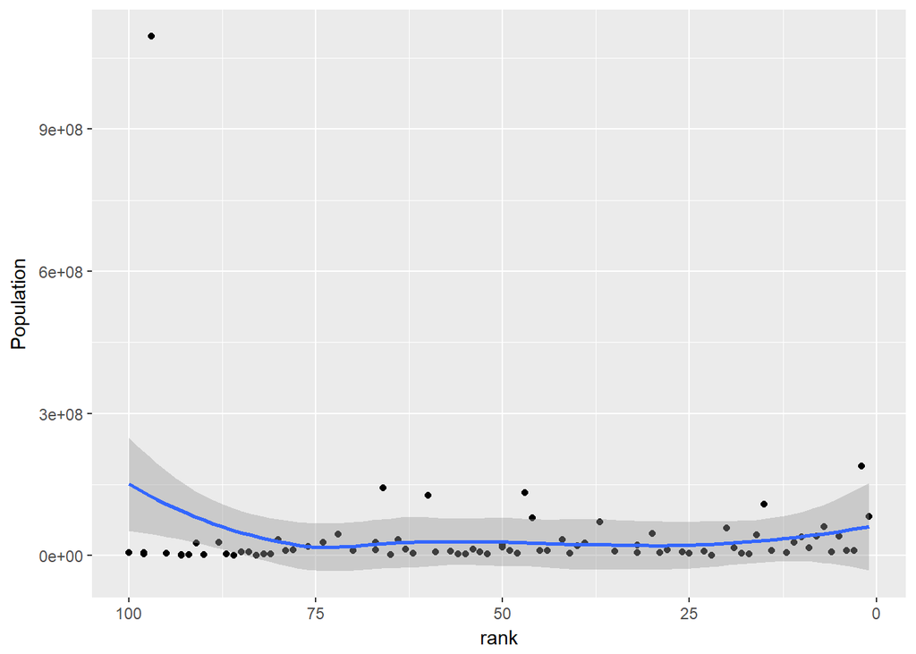

```r
trim <- function (x) gsub("^\\s+|\\s+$", "", x)
replace_ampersand <- function (x) gsub("&", "and", x)
replace_the <- function (x) gsub(", The", "", x)
ranking <- fifa.ranking
colnames(ranking)[2] <- "Country"

ranking$Country <- sapply(ranking$Country, function(x) trim(x))
country.data$Country <- sapply(country.data$Country, function(x) trim(x))
country.data$Country <- sapply(country.data$Country, function(x) replace_ampersand(x))
country.data$Country <- sapply(country.data$Country, function(x) replace_the(x))
ranking$rank_date <- lubridate::ymd(ranking$rank_date)
mdata <- subset(ranking, ranking$rank_date > "2018-05-01")

mdata <- merge(x = mdata, y = country.data, by = "Country", all.x = T)

mdata <- na.omit(mdata)
mdata <- mdata[order(mdata$rank),]

mdata.top100 <- subset(mdata, mdata$rank <= 100)

mdata.top100 %>% ggplot(aes(x = rank, y = Population)) +
  scale_x_reverse(limits=c(100,1)) +
  geom_point() +
  geom_smooth()
```

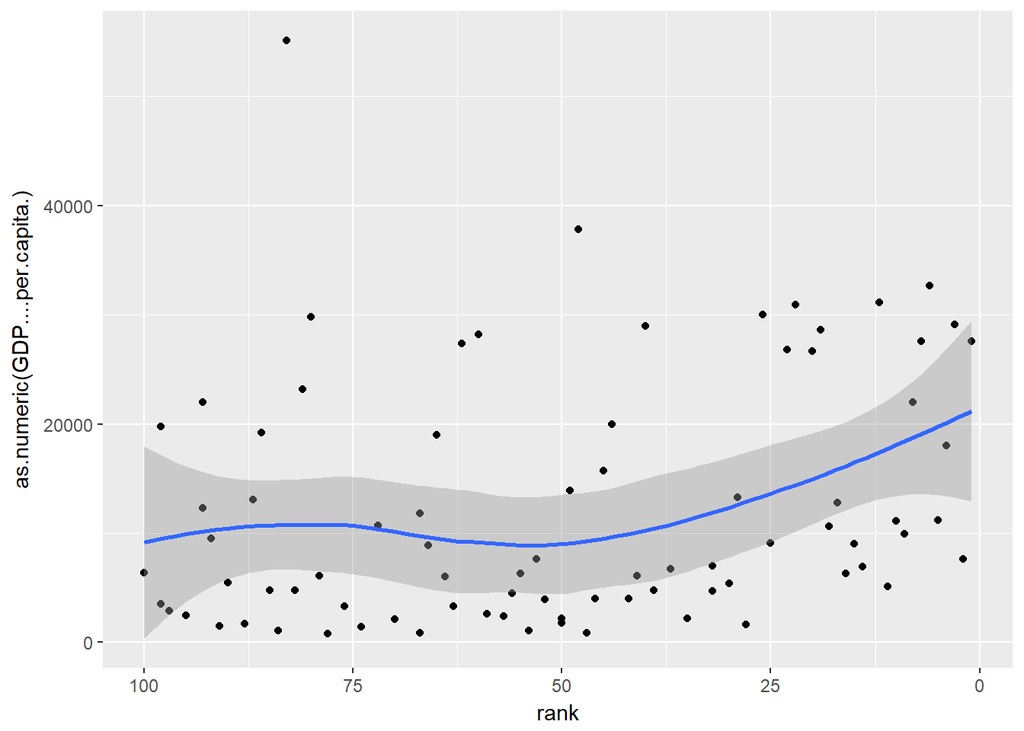

```r
mdata.top100 %>% ggplot(aes(x = rank, y = as.numeric(GDP....per.capita.))) +
  scale_x_reverse(limits=c(100,1)) +
  geom_point() +
  geom_smooth()
```

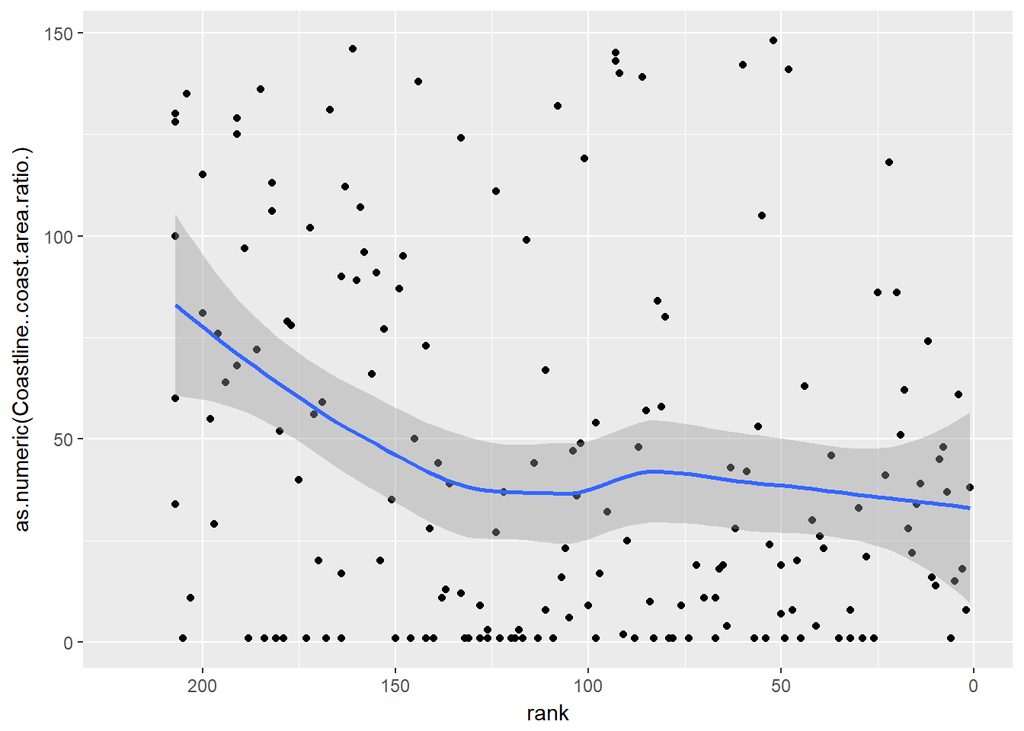

```r
mdata %>% ggplot(aes(x = rank, y = as.numeric(Coastline..coast.area.ratio.))) +
  scale_x_reverse(limits=c(220,1)) +
  geom_point() +
  geom_smooth()
```

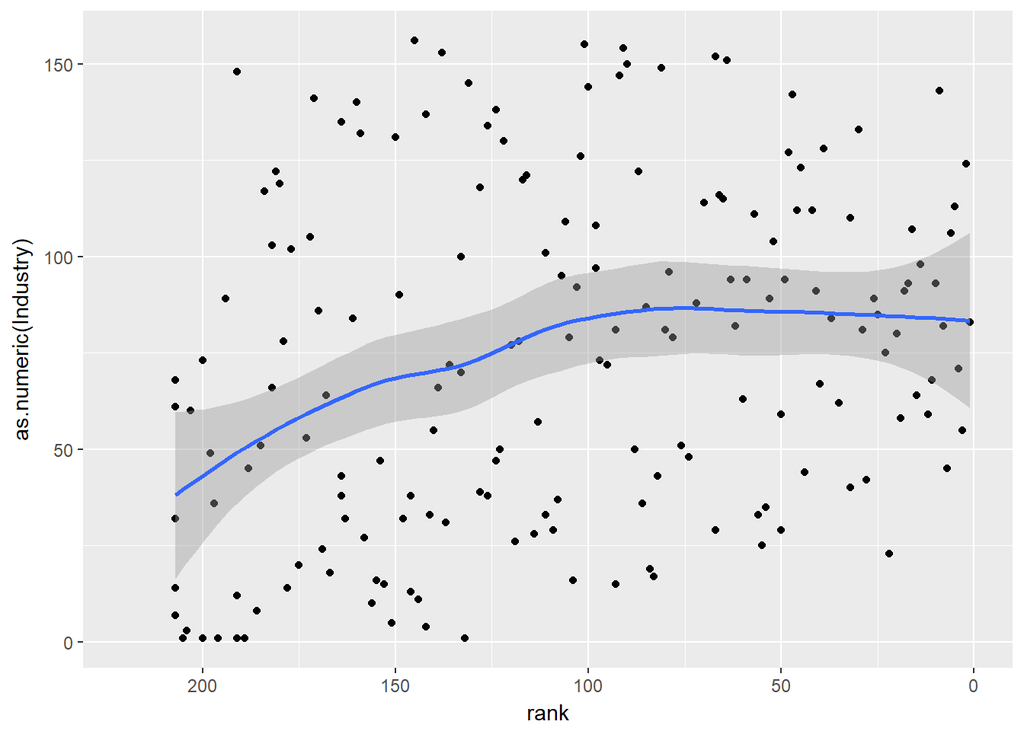

```r
mdata %>% ggplot(aes(x = rank, y = as.numeric(Industry))) +
  scale_x_reverse(limits=c(220,1)) +
  geom_point() +
  geom_smooth()
```

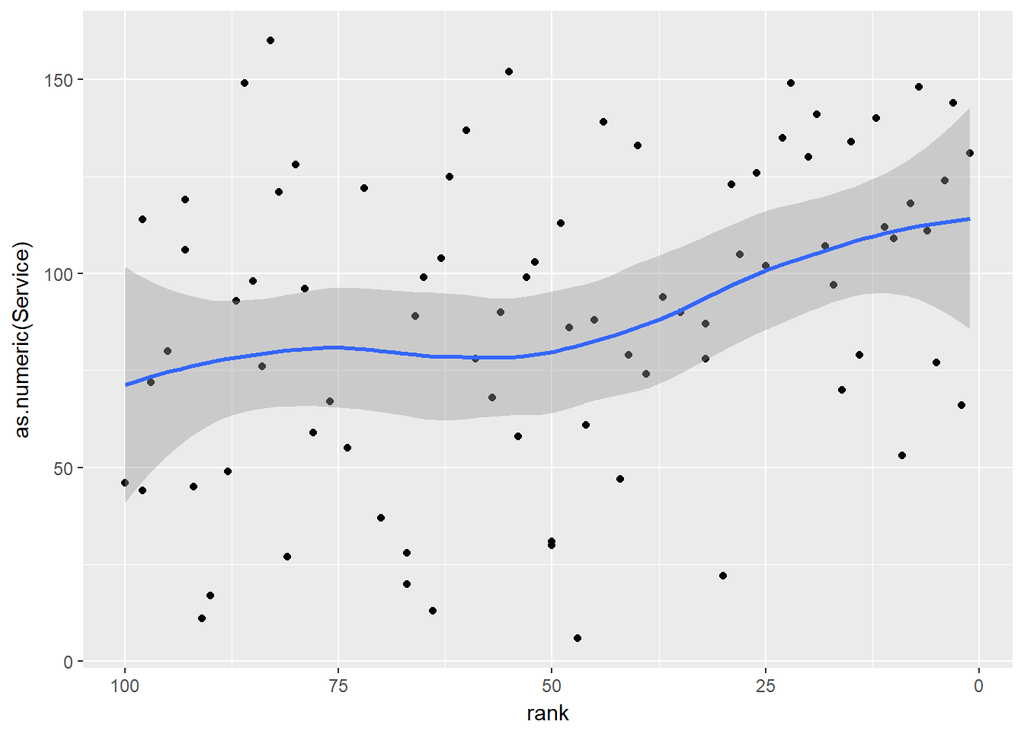

```r
mdata.top100 %>% ggplot(aes(x = rank, y = as.numeric(Service))) +
  scale_x_reverse(limits=c(100,1)) +
  geom_point() +
  geom_smooth()
```

### Evaluation

- **Task 13.** Implement the evaluation metric. This is a function with two arguments: the prediction matrix $R$ and a data structure with the true results $R_{true}$. Note, that this data structure should not be a matrix since two teams may compete twice against each other during the course of a world cup tournament. What data structure would you suggest?

```r
#' compute fraction of correct predictions
#'
#'@param R anti-symmetric matrix of prediction results [row=Home, col=Away]
#'@param R_true dataframe containing [Home, Away, Result] whereas Result is one of [W,D,L]
evaluate <- function(R, R_true) {
  R_true$Predict <- apply(R_true, 1, function(x) R[x['Home'],x['Away']])
  eval <- R_true %>% summarize(n = n(), n_correct = sum(Result == Predict))
  return(eval$n_correct/eval$n)
}
```

- **Task 14.** Generate a matrix of random predictions to test this function. Don’t forget, that this matrix is symmetric and that the diagonal should only contain NAs.

```r
Wc.matches.2014 <- WC.matches %>% filter(Year==2014)
Teams.2014 <- Wc.matches.2014 %>% distinct(Team.Initials)
R_random <- matrix(,32,32)
random_results <- sample(c('W','D','L'),496, replace=TRUE)
inverse_results <- sapply(random_results, function (x) switch(x, "W"="L", "L"="W", "D"))
R_random[lower.tri(R_random, diag=F)] <- random_results
R_random <- t(R_random)
R_random[lower.tri(R_random, diag=F)] <- inverse_results
rownames(R_random) <- lapply(Teams.2014$Team.Initials, as.character)
colnames(R_random) <- lapply(Teams.2014$Team.Initials, as.character)
```

- **Task 15.** Generate (hypothetic) true results and test the function of Task 14.

```r
Test.2014 <- Wc.matches.2014 %>% select(Home = Team.Initials, Away = Opponent.Initials, Result)
res <- evaluate(R_random, Test.2014)
cat("Accuracy:", res)
```

```
## Accuracy: 0.3846154
```

```r
# save everything to file
save.image(file='WCBC.RData')
```

- **Task 16.** A completely naive predictor, which randomly predicts the outcome with equal probabilites, should serve as a benchmark. What is the expected rate of correct predictions?

0.33, as the chance to draw the correct result is 1/3 (if we assume that each outcome of a match has the same probability).